# iDEP: Investigating Differentially Expressed Genes

## If this site has contributed to your work, please cite our article:

Ge, S.X., Son, E.W. & Yao, R. iDEP: an integrated web application for differential expression and pathway analysis of RNA-Seq data. BMC Bioinformatics 19, 534 (2018). https://doi.org/10.1186/s12859-018-2486-6

## Summary

Read Counts data were analyzed using iDEP v2.4.4. The data was first filtered to remove reads below 0.5 CPM in at least 1 sample. Then the data was transformed with EdgeR using a pseudocount of 4. Missing values were imputed using geneMedian.

After mapping, there are 32833 unique genes in 158 samples. Of the 24127 genes passed filter, 24127 were converted to Ensembl/STRING gene IDs in our database. The remaining 0 genes were kept in the data using original IDs.

Differential expression analysis was performed using DESeq2 with an FDR cutoff of 0.1 and a minimum fold-change threshold of 2. Standard Wald test was used and independent filtering was enabled.

## Selected Comparison: genotypeSOG11-genotypeWILDTYPE

Up-regulated genes: 426

Down-regulated genes: 504

## Top Up-regulated Genes

```r
if (!is.null(params$up_genes_table) && nrow(params$up_genes_table) > 0) {
  kbl(params$up_genes_table, escape = FALSE) %>%
    kable_classic(full_width = FALSE, html_font = "Cambria")
} else {
  print("No up-regulated genes found for this comparison.")
}
```

| Symbol | Ensembl ID | log2 FC | Adj. P-value | Description |
| --- | --- | --- | --- | --- |
| AT5G41025 | AT5G41025 | 21.108 | 1.55e-06 | Uncharacterized protein |
| AT5G28370 | AT5G28370 | 21.036 | 1.71e-06 | Pentatricopeptide repeat (PPR) superfamily protein |
| AT1G12830 | AT1G12830 | 20.347 | 2.66e-06 | Nucleolin |
| AT4G02720 | AT4G02720 | 19.738 | 5.56e-06 | Ras-induced vulval development antagonist protein |
| AT2G18270 | AT2G18270 | 17.811 | 7.00e-05 | Uncharacterized protein |
| AT3G60420 | AT3G60420 | 16.463 | 2.75e-04 | Phosphoglycerate mutase family protein |
| CYP71B21 | AT3G26190 | 15.345 | 8.74e-05 | Cytochrome P450, family 71, subfamily B, polypeptide 21 |
| AT1G24388 | AT1G24388 | 10.945 | 6.56e-250 | Uncharacterized protein |
| AT1G27580 | AT1G27580 | 10.742 | 1.17e-146 | F-box protein (DUF295) |
| AT1G06103 | AT1G06103 | 9.874 | 2.00e-198 | NcRNA |
| AT1G27570 | AT1G27570 | 9.721 | 9.47e-196 | Phosphatidylinositol 3- and 4-kinase family protein |
| AT1G24390 | AT1G24390 | 8.225 | 4.60e-135 | Uncharacterized protein |
| AT2G01422 | AT2G01422 | 6.951 | 3.31e-60 | NcRNA |
| AT1G25025 AT1G25025 | AT1G25025 | 6.858 | 6.24e-77 | Uncharacterized protein |
| AT1G25025 AT1G25112 | AT1G25112 | 6.858 | 6.24e-77 | Uncharacterized protein |
| AT1G06407 | AT1G06407 | 5.533 | 1.30e-71 | NcRNA |
| AT1G10110 | AT1G10110 | 5.157 | 3.47e-230 | F-box family protein |
| AT2G15555 | AT2G15555 | 5.137 | 4.57e-44 | NcRNA |
| AT5G45180 | AT5G45180 | 4.907 | 1.46e-02 | Flavin-binding monooxygenase family protein |
| AT1G20590 | AT1G20590 | 4.794 | 7.94e-28 | Cyclin |
| AT1G12340 | AT1G12340 | 4.792 | 6.59e-140 | Cornichon family protein |
| AT1G22120 | AT1G22120 | 4.644 | 9.53e-28 | Uncharacterized protein |
| AT1G25180 | AT1G25180 | 4.599 | 1.15e-34 | Uncharacterized protein |
| AT2G24683 | AT2G24683 | 4.570 | 1.55e-41 | Uncharacterized protein |
| PCR1 | AT1G14880 | 4.506 | 5.73e-28 | PLANT CADMIUM RESISTANCE 1 |
| AT1G14800 | AT1G14800 | 4.418 | 7.55e-10 | Nucleic acid-binding, OB-fold-like protein |
| AT1G35170 | AT1G35170 | 4.248 | 5.30e-30 | TRAM, LAG1 and CLN8 (TLC) lipid-sensing domain containing protein |
| AT2G09975 | AT2G09975 | 4.194 | 1.44e-03 | NcRNA |
| AT1G02770 | AT1G02770 | 4.118 | 4.63e-287 | Uncharacterized protein |
| AT2G12905 | AT2G12905 | 4.065 | 2.25e-09 | Uncharacterized protein |
| AT1G34047 | AT1G34047 | 3.925 | 4.27e-53 | Defensin-like (DEFL) family protein |
| AT1G28590 | AT1G28590 | 3.587 | 3.44e-59 | GDSL-like Lipase/Acylhydrolase superfamily protein |
| CYP710A4 | AT2G28860 | 3.501 | 5.38e-29 | Cytochrome P450, family 710, subfamily A, polypeptide 4 |
| AT2G08735 | AT2G08735 | 3.477 | 2.46e-35 | NcRNA |
| AT2G24681 | AT2G24681 | 3.415 | 5.61e-46 | AP2/B3-like transcriptional factor family protein |
| APD3 | AT2G38220 | 3.414 | 1.54e-35 | RING/U-box superfamily protein |
| AT4G04223 | AT4G04223 | 3.380 | 2.16e-118 | NcRNA |
| SDG21 | AT2G24740 | 3.380 | 6.81e-21 | SET domain group 21 |
| AT5G34780 | AT5G34780 | 3.342 | 2.38e-04 | Thiamine diphosphate-binding fold (THDP-binding) superfamily protein |
| AT1G10875 | AT1G10875 | 3.326 | 1.47e-04 | Core-2/I-branching beta-1,6-N-acetylglucosaminyltransferase family protein |
| AT5G01645 | AT5G01645 | 3.317 | 3.16e-04 | NcRNA |
| AT1G06277 | AT1G06277 | 3.314 | 7.16e-04 | NcRNA |
| AT2G18025 | AT2G18025 | 3.280 | 4.21e-08 | Uncharacterized protein |
| AT1G28650 | AT1G28650 | 3.206 | 6.28e-28 | GDSL-like Lipase/Acylhydrolase superfamily protein |
| AT1G27540 | AT1G27540 | 3.176 | 0.00e+00 | F-box protein (DUF295) |
| AT1G06447 | AT1G06447 | 3.134 | 1.63e-02 | NcRNA |
| AT2G27650 | AT2G27650 | 3.090 | 1.20e-36 | Ubiquitin carboxyl-terminal hydrolase-related protein |
| AT2G05695 | AT2G05695 | 3.071 | 2.27e-06 | NcRNA |
| AT1G03106 | AT1G03106 | 3.031 | 4.63e-34 | Uncharacterized protein |
| LURP1 | AT2G14560 | 3.025 | 5.60e-17 | LURP-one-like protein (DUF567) |

## Top Down-regulated Genes

```r
if (!is.null(params$down_genes_table) && nrow(params$down_genes_table) > 0) {
  kbl(params$down_genes_table, escape = FALSE) %>%
    kable_classic(full_width = FALSE, html_font = "Cambria")
} else {
  print("No down-regulated genes found for this comparison.")
}
```

| Symbol | Ensembl ID | log2 FC | Adj. P-value | Description |
| --- | --- | --- | --- | --- |
| AT1G07500 | AT1G07500 | -29.981 | 0.00e+00 | Uncharacterized protein |
| AT4G09815 | AT4G09815 | -29.659 | 2.81e-12 | NcRNA |
| AT4G09250 | AT4G09250 | -29.574 | 6.53e-28 | SPla/RYanodine receptor (SPRY) domain-containing protein |
| AT4G06685 | AT4G06685 | -22.397 | 1.71e-51 | NcRNA |
| AT2G15292 | AT2G15292 | -9.657 | 3.31e-201 | NcRNA |
| AT2G31150 | AT2G31150 | -9.234 | 3.29e-182 | ATP binding / ATPase |
| AT2G14460 | AT2G14460 | -8.772 | 3.56e-160 |  |
| RPS5 | AT1G12220 | -8.671 | 3.99e-160 | Disease resistance protein (CC-NBS-LRR class) family |
| AT1G52905 | AT1G52905 | -8.063 | 2.61e-142 | Uncharacterized protein |
| AT2G28990 | AT2G28990 | -7.855 | 3.98e-125 | Leucine-rich repeat protein kinase family protein |
| AT1G09995 | AT1G09995 | -7.776 | 1.23e-126 | DNA repair DEAD helicase RAD3/XP-D subfamily protein |
| AT2G24945 | AT2G24945 | -7.735 | 9.01e-127 | Uncharacterized protein |
| AT1G34844 | AT1G34844 | -7.692 | 1.56e-126 | NcRNA |
| AT1G14250 | AT1G14250 | -7.528 | 1.01e-96 | GDA1/CD39 nucleoside phosphatase family protein |
| AT1G15885 | AT1G15885 | -7.120 | 1.20e-104 | Uncharacterized protein |
| eIF4E3 | AT1G29590 | -6.986 | 1.16e-102 | Translation initiation factor |
| U2.11 | AT1G04733 | -6.887 | 1.47e-60 | NcRNA |
| AT1G30160 | AT1G30160 | -6.599 | 6.28e-92 |  |
| PP2-A3 | AT2G26820 | -6.515 | 1.29e-89 | Phloem protein 2-A3 |
| AT2G27402 | AT2G27402 | -6.279 | 0.00e+00 | Plastid transcriptionally active protein |
| AT1G15890 | AT1G15890 | -5.986 | 9.20e-99 | Disease resistance protein (CC-NBS-LRR class) family |
| AT5G07265 | AT5G07265 | -5.948 | 2.67e-02 | NcRNA |
| AT1G32570 | AT1G32570 | -5.918 | 1.69e-75 | Uncharacterized protein |
| AT1G10000 | AT1G10000 | -5.906 | 2.05e-71 | Ribonuclease H-like superfamily protein |
| AT1G29600 | AT1G29600 | -5.804 | 6.18e-81 | Zinc finger C-x8-C-x5-C-x3-H type family protein |
| AT1G31258 | AT1G31258 | -5.669 | 1.05e-62 | NcRNA |
| ATMG01090 | ATMG01090 | -5.666 | 1.48e-57 |  |
| AT4G16610 | AT4G16610 | -5.636 | 1.24e-100 | C2H2-like zinc finger protein |
| AT1G19394 | AT1G19394 | -5.578 | 9.70e-61 | Uncharacterized protein |
| AT5G07165 | AT5G07165 | -5.481 | 3.87e-21 | Uncharacterized protein |
| AT1G24851 | AT1G24851 | -5.391 | 1.19e-58 | Uncharacterized protein |
| GLR2.7 | AT2G29120 | -5.382 | 5.45e-163 | Glutamate receptor 2.7 |
| AT2G32160 | AT2G32160 | -5.366 | 4.89e-57 | S-adenosyl-L-methionine-dependent methyltransferases superfamily protein |
| AT2G14878 | AT2G14878 | -5.318 | 0.00e+00 | NcRNA |
| AT1G45163 | AT1G45163 | -5.306 | 4.12e-71 | Uncharacterized protein |
| AT1G35320 | AT1G35320 | -5.282 | 0.00e+00 | Uncharacterized protein |
| AT1G06577 | AT1G06577 | -5.126 | 1.55e-41 | NcRNA |
| AT1G25141 | AT1G25141 | -5.115 | 3.39e-58 | F-box associated ubiquitination effector family protein |
| AT1G06587 | AT1G06587 | -5.112 | 7.06e-46 | NcRNA |
| AT1G04313 | AT1G04313 | -5.058 | 3.13e-54 | NcRNA |
| AT1G20400 | AT1G20400 | -5.053 | 4.08e-47 |  |
| AT1G20750 | AT1G20750 | -5.042 | 1.94e-29 | RAD3-like DNA-binding helicase protein |
| AT1G64795 | AT1G64795 | -4.936 | 1.94e-53 | Uncharacterized protein |
| AT1G45165 | AT1G45165 | -4.819 | 6.97e-50 | Uncharacterized protein |
| AT3G27630 | AT3G27630 | -4.770 | 1.30e-50 | Cyclin-dependent kinase inhibitor SMR3-like protein |
| AT2G18720 | AT2G18720 | -4.600 | 1.61e-50 | Translation elongation factor EF1A/initiation factor IF2gamma family protein |
| AT1G06243 | AT1G06243 | -4.565 | 2.32e-29 | NcRNA |
| AT1G24145 | AT1G24145 | -4.538 | 1.04e-52 | Uncharacterized protein |
| AT2G22821 | AT2G22821 | -4.474 | 7.58e-37 | NcRNA |
| AT1G04357 | AT1G04357 | -4.410 | 3.33e-40 | NcRNA |

## DEG Heatmap

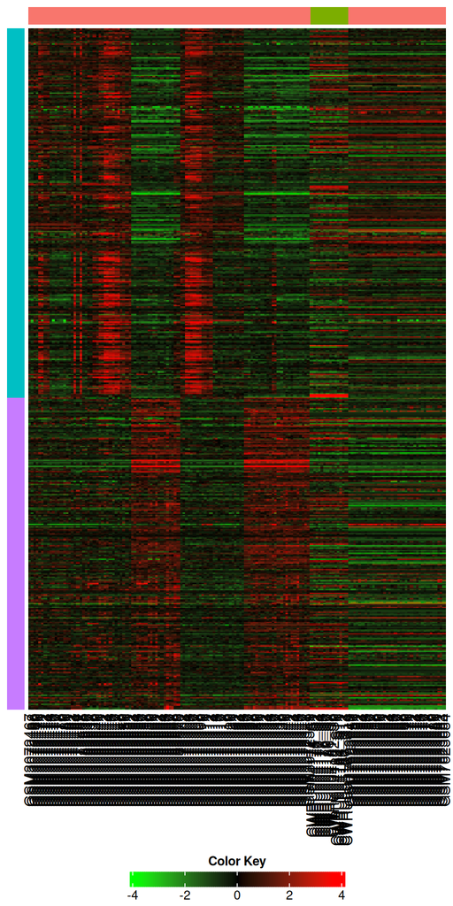

```r
if (!is.null(params$heat_data) && !is.null(params$heat_bar)) {
  heat_colors <- unlist(strsplit(params$heatmap_color_select, "-"))

  deg_heatmap(
    df = params$heat_data,
    bar = params$heat_bar,
    heatmap_color_select = heat_colors,
    cluster_rows = FALSE
  )
}
```

## Volcano Plot

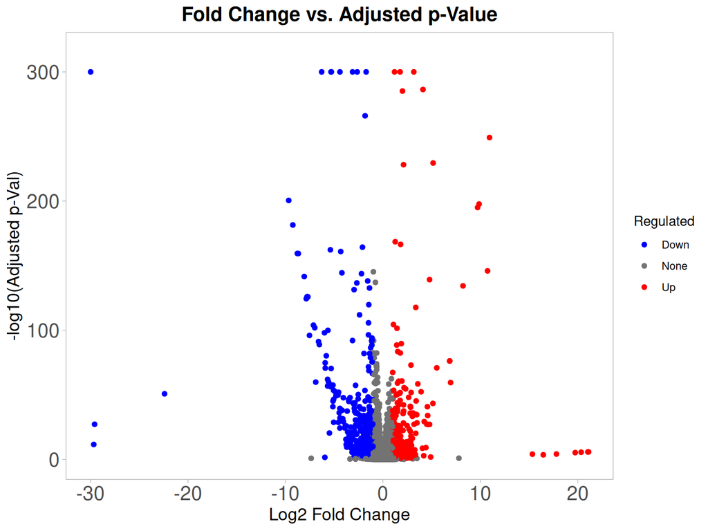

```r
if (!is.null(params$vol_data) && !is.null(params$vol_data$data)) {
  p <- plot_volcano(
    data = params$vol_data$data,
    plot_colors = params$plot_colors,
    anotate_genes = params$gene_labels_volcano
  )
  p <- refine_ggplot2(
    p = p,
    gridline = params$plot_grid_lines,
    ggplot2_theme = params$ggplot2_theme
  )
  print(p)
}
```